# Aids Drug

Cortajha Hunter

12/4/2019

# Introduction

A new preventative aides (abacavirinol) is under test in clinical trials. Analyze the effectiveness of this drug across the board. Consider population subgroups by gender, drug use, and sexual orientation.Next, we will conduct an evaluation of drugs efficicacy for all of the pateints. Following behind that, we conduct an evaluation specifically for the women. After both evaluations are complete, we are going to conduct one more evaluation of drugs efficacy specifically for the males. Finally, we evaluate an drug efficacy specifically for the patients who consumes drugs, following that, an efficacy for the LBGTQ.

# Methods

There are a total of five test, which are all categorical. Was the vaccine affective for each of the five categories?

#Results

Question 1: Is the vaccine effective?

$H_0$ The vaccine affects if one was to come in contacts with aids

$H_0$ The vaccine has no effect

The vaccine affects poeple only if they came in contact with aids, and if one have not came in contact with aids then the vaccine has absolutely no affect.

```r
all=xtabs(~infected+treatment, data=avast)
rowPerc(all)
```

```
##         treatment
## infected   drug placebo  Total
##     aids  40.87   59.13 100.00
##     none  49.10   50.90 100.00
```

This chart specifys that people that took the placebo had a higher percentage than the people that took the drug.

```r
chisqtestGC(all, data= avast)
```

```
## Pearson's Chi-squared test with Yates' continuity correction
##
## Observed Counts:
##         treatment
## infected  drug placebo
##     aids   423     612
##     none 10168   10540
##
## Counts Expected by Null:
##         treatment
## infected     drug  placebo
##     aids   504.15   530.85
##     none 10086.85 10621.15
##
## Contributions to the chi-square statistic:
##         treatment
## infected  drug placebo
##     aids 13.06   12.40
##     none  0.65    0.62
##
##
## Chi-Square Statistic = 26.4104
## Degrees of Freedom of the table = 1
## P-Value = 0
```

## Descriptive Results

### Graphical Descriptive Results

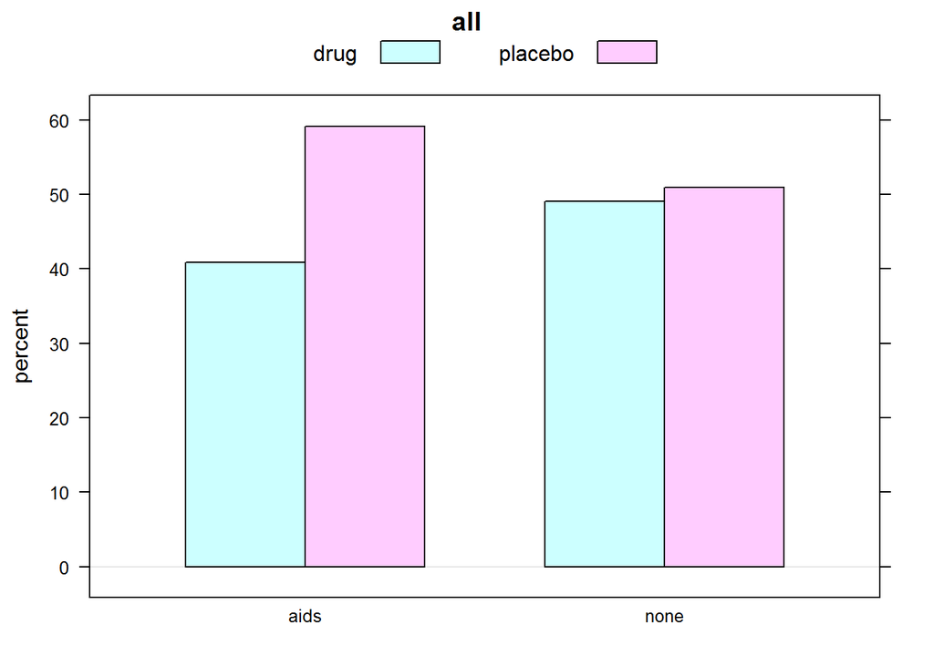

```r
barchartGC(~infected+treatment,type="percent",main="all")
```

The people with aids were least affected by the drug and more affected by the plcebo. Wheres the people without aids were affected by both the drug and the pleacebo, greatly.

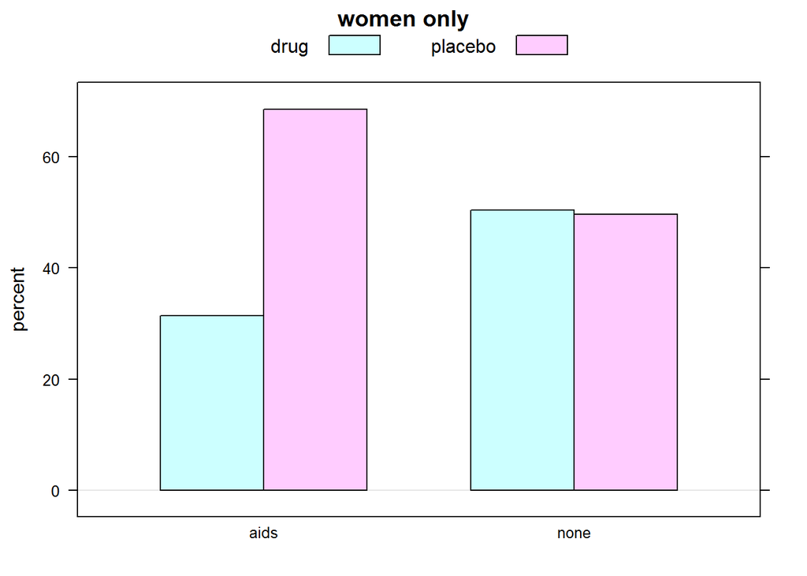

```r
barchartGC(~infected+treatment, data=filter(avast, sex=='gal'), main='women only', type='percent')
```

The women with aids were greatly affected by the placebo, while they were least affected by the drug. Women without aids were evenly affected by the drug and and placebo.

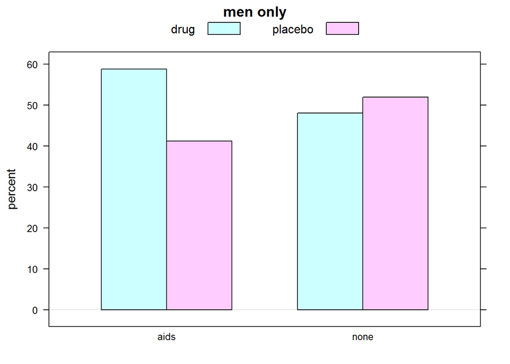

```r
barchartGC(~infected+treatment, data=filter(avast, sex=='guy'), main='men only', type='percent')
```

The men with aids were greatly affected by the drug and slightly less when it came to the placebo. While men without aids were both closely affected the drug and the placebo.

[figure not shown]

```r
barchartGC(~infected+treatment, data=filter(avast, sex=='gal'), main='DrugUsers', type='percent')
```